# Algorithm Class 43 - Design 5

System Design 1: Overview and Architecture

July/22/2019

# 1 Overview

主要通過這一課, 介紹一下系統設計的一些基礎知識點, 給大家一個基本的印象.

通過講一個典型的Web系統, 給大家一個基本的概念, 其實是希望大家對系統設計有一個比較基礎的認識.

## 1.1 系統設計的面試的意義

- 小公司一般用系統設計來考察面試者的知識面以及基礎, 從而得出是否可以迅速的上手實際工作.
- 大公司一般用來考察面試者的工作經驗, 是否參與過System Design的相關工作, 是否有相關的背景, 基本用此來衡量面試者的Level.
- 後面講例子的時候再具體説明系統設計面試一般都如何進行, 以及考察點具體是什麽.

## 1.2 系統設計定義

系統設計是爲滿足特定的需求, 爲一個系統制定架構, 模塊, 接口和數據結構的過程.

System design is the process of defining the architecture, modules, interfaces, and data for a system to satisfy specified requirements.

- 需求
- 架構
- 模塊
- 接口
- 數據

## 1.3 區別於算法設計

算法:

- 解決一個非常具體的問題, example: 2sum, 3sum.
- 算法的正確性是可驗證的, 絕對的, 給定輸入, 結果一致.
- 算法的效率通常可以直觀的分析出來, 時間複雜度, 空間複雜度等.

系統設計:

- 通常用於解決一系列的需求.
- 涉及到多方面, 系統的知識, 包括算法, 面向對象的設計, 計算機及網絡原理, 分佈式系統, 典型的系統架構, 大數據處理等等.
- 更注重於規範和定義系統中的各個部分以及各部分之間的關係.
- 並不存在絕對的正確, 通常側重於trade off的討論, 當然需要滿足主要需求

## 1.4 區別於面向對象設計

- 側重點不同, 面向對象設計更側重於數據對象的抽象, 而系統設計則側重在系統.
- 比如設計一個停車場:
  - 面向對象設計的時候, 側重在車, 停車場的抽象表達, 突出車的屬性, 車的基本操作, 停車場屬性, 停車場基本操作, 車與停車場的關係.
  - 系統設計的時候, 側重在停車場怎麽設計, 停車場怎麽停放車輛, 能夠停放的容量, 停放時候有一定的規則, 停車場開放時間, 車怎麽進入停車場, 如何收費, 怎麽出停車場, 超市怎麽辦, 等等.

## 1.5 系統設計要素

需求:

- 功能需求: 直觀, 簡單地說就是需要系統解決什麽問題. 比如: 搜索引擎系統解決搜索的問題, 導航系統解決導航.
- 性能需求: 并不完全直觀, 通常隱藏在功能需求之下. 比如: 搜索多久能返回結果, 導航是不是能獲取最高效路徑等等.
- 資源需求: 隱藏, 經驗性的. 包括: 計算資源, 網絡資源, 時間資源等等都屬於.

系統:

- 完整的解決方案
- 架構
- 硬件
- 軟件
- 流程

設計:

- 解決問題
- 優先級的劃分
- 方案的選擇和評價

# 2 Architecture

## 2.1 典型系統 - Yelp

[figure not shown]

### 2.1.1 需求

- 功能(分用戶類型)
  - 商家: 發佈信息, 反饋用戶review, 預定, 外賣
  - 個人用戶: 地理範圍餐廳搜索(細化), 查看評論和基本信息, 發表評論, 預定, 廣告
- 性能
  - 支持多少用戶同時在綫
  - 搜索反饋的時間
  - 支持多少商家
  - Availability, Flexibility, Scalability, Extensibility
- 資源
  - 整個系統設計的硬件資源
  - 軟件資源
  - 流程資源

### 2.1.2 系統本身

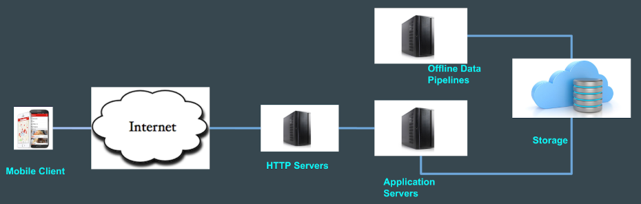

- Client終端
  - 終端的作用
    - 與用戶的交互
      1. 内容呈現
      2. 功能的體現
      3. 用戶輸入(文字, 圖形, 其他形)
    - 與後端的信息交流
    - 數據的本地緩存
    - 與其他終端應用的交互, 比如Map, Phone call
  - Web, iOS, Android, 各類其他平臺
    - 編程語言差別
    - 平臺的API的支持差別
    - 成型的library差別
  - 終端的選擇
    - 用戶群體
    - 場景
    - Web的退化
- HTTP Server
  - [HTTP](http://www.ntu.edu.sg/home/ehchua/programming/webprogramming/http_basics.html) is the abbreviation of “HyperText Transfer Protocol”. A protocol is like a language with a simple grammar. The HTTP Server is the implementation of that protocol in a piece of Software.
  - HTTP支持的操作: GET, POST, PUT, DELETE.
  - Example: https://httpd.apache.org/ path.
  - HTTP是應用層協議, 在Web出現的初期, 所有的Web都用HTTP協議的方式來完成前後端的通信, 也被沿用到Mobile時代.
  - HTTP Server是用於處理和響應終端的HTTP請求的, 然後根據不用請求的需求, 分發到相應的應用服務器(Application Server).
  - [RESTFUL API](https://restfulapi.net/rest-api-design-tutorial-with-example/)是比較典型的HTTP的現代應用.
    - Representational State Transfer
    - Resource: 資源, 即數據(前面説過網絡的核心). 比如newsfeed, friends等
    - Representational: 某種表現形式, 比如用JSON, XML, JPEG等
    - State Transfer: 狀態變化, 用過HTTP動詞實現
  - HTTP Server支持的操作: GET, POST, PUT, DELETE.
    - https://www.yelp.com/ GET
    - https://www.yelp.com/search?find_desc=Restaurants&find_loc=Willow+Glen%2C+San+Jose%2C+CA&ns=1 POST
- Application Server(應用服務器)
  - An application server is a software framework that provides both facilities to create web applications and a server environment to run them.
    - 簡單點講, 處理具體的業務邏輯
    - 舉個例子:
      1. https://www.yelp.com/search?find_desc=Restaurants&find_loc=Willow+Glen%2C+San+Jose%2C+CA&ns=1
      2. 當HTTP Server搜到這個請求以後, 主要事件:
         1. 判斷這個發起者有沒有權利這麽做
         2. 根據搜索關鍵詞給出結果(包含所有的基礎信息)
         3. 廣告
         4. …
    - 典型的Application Server:
      1. .NET application server遠古時期
      2. PHP application server也挺遠古的, Facebook最初就是基於PHP的application server搭建的
      3. J2EE中生代
      4. Ruby on Rail曾經的輝煌
      5. Tomcat
      6. Node JS
      7. 主流的Cloud都推出了自己的Serverless application platform概念
    - Server Cookies
- Storage
  - 數據庫: 關係數據庫, 非關係數據庫, SQL
  - 文件系統: 網絡文件系統, DFS, 本地
  - cache
- Offline Data Pipeline
  - 對數據的後臺處理, 用於支持特定的功能
  - 比如個人定制化P13n, Ranking算法, search算法等等
  - Map Reduce / Flume / Streaming Data Processing / Spark / Tensorflow
- Internet
  - 網絡通信, 所有以上各個部分之間的聯係
  - [網絡協議](https://www.geeksforgeeks.org/computer-network-tcpip-model/)
  - http://www.yelp.com/search?xxxxx “建立連接, 尋址, DNS, 經過router”
    1. HTTP Request. GET HTTP
       - Host + port + path, 10.1.1.1/
    2. 5層網絡協議: https://www.ischool.utexas.edu/~wyllys/ITIPMaterials/NotesOnInterconnection.html
    3. TCP. port to port. HTTP. 80
    4. http://www.yelp.com/asdfa 192.169.0.1/asdfas 192.168.0.1:8080/adfasdfasdf
    5. TCP connection. 負責端到端, 可信賴通信. HTTP -> http://www.yelp.com Byte Server receive
    6. Sync, ACK Sync, ACK
    7. HTTP Request操作類型: GET, PUT, POST, DELETE

    ```
    GET /index.html HTTP/1.1
    Host: www.example.com
    ```

    8. HTTP1.0-HTTP1.1
    9. IP
       - HOST file. Domain name.
       - DNS Domain name service: Tree structure.

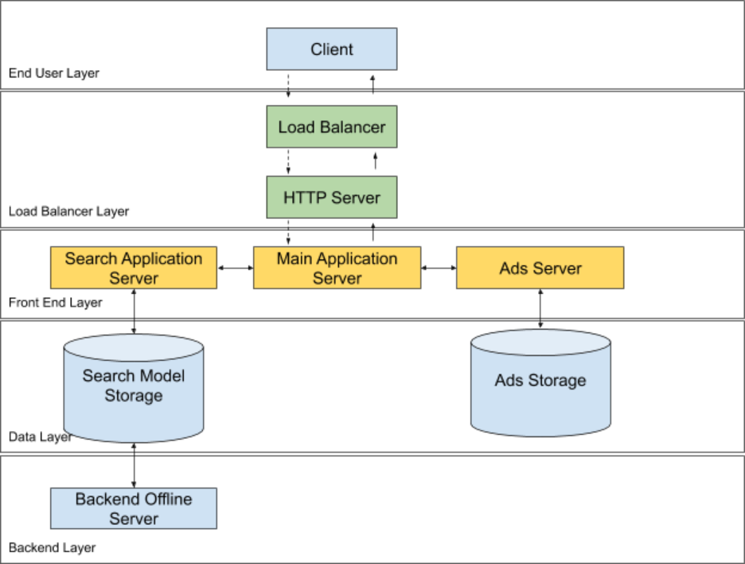